# Colby RUG –`tidyr` v 1.0

Manny Gimond

2019.10.29

This tutorial will cover many of the new and existing functions available in the `tidyr` package version `1.0`. It will also discuss changes in some of the more popular functions used in reshaping data tables.

> Before continuing, make sure to load the `tidyr` package.

```r
library(tidyr)
```

## Wide and long versions of a table

A 2014 Boston (Logan airport) flight data summary table will be used in this example. The summary displays average mean delay times (in minutes) by day of the week and quarter.

```r
df <- data.frame( Weekday = c( "Mon", "Tues", "Wed", "Thurs", "Fri" ),
                  Q1      = c(  9.9 ,  4.9  ,  8.8 ,   12.2 ,  12.2 ),
                  Q2      = c(  5.4 ,  9.7  , 11.1 ,   10.2 ,   8.1 ),
                  Q3      = c(  8.8 ,  7.9  , 10.2 ,   9.2  ,   7.9 ),
                  Q4      = c(  6.9 ,    5  ,  9.3 ,   9.7  ,   5.6 ))
```

```r
df
```

```
  Weekday   Q1   Q2   Q3  Q4
1     Mon  9.9  5.4  8.8 6.9
2    Tues  4.9  9.7  7.9 5.0
3     Wed  8.8 11.1 10.2 9.3
4   Thurs 12.2 10.2  9.2 9.7
5     Fri 12.2  8.1  7.9 5.6
```

There are three unique variables: day of week, quarter of year, and mean departure delay.

### Creating a long table from a wide table: `pivot_longer`

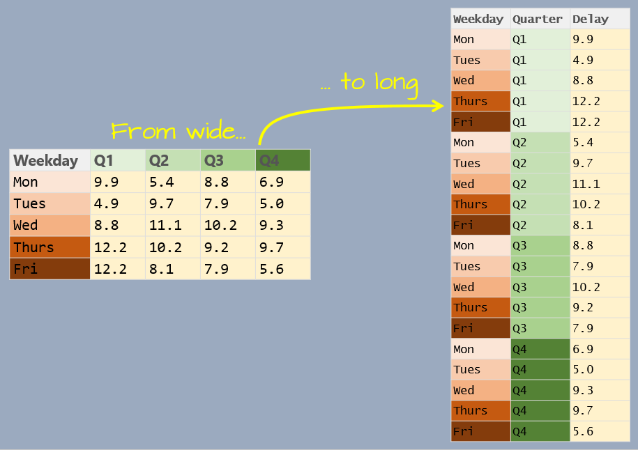

To go from wide to long we use the `pivot_longer` function. This replaces the `gather()` function from earlier versions of `tidyr` (<`1.0`).

The `pivot_longer` function takes at least three arguments:

- `cols`: list of columns that are to be collapsed. The columns can be referenced by column number or column name. Note that the column enumeration does not need to be wrapped in a `c()` function.
- `names_to`: This is the name of the new column which will combine all column names (e.g. Q1, Q2, Q3 and Q4).
- `values_to`: This is the name of the new column which will combine all column values (e.g. average delay times) associated with each variable combination (e.g. Mon and Q1, Tues and Q1, etc…)

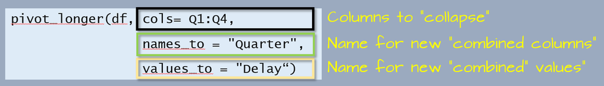

In our example, the line of code needed to re-express the table into a long form can be written in several ways:

```r
df.long <- pivot_longer(df, cols=2:5, names_to = "Quarter", values_to = "Delay")
# or
df.long <- pivot_longer(df, cols=-1, names_to = "Quarter", values_to = "Delay")
# or
df.long <- pivot_longer(df, cols=Q1:Q4, names_to = "Quarter", values_to = "Delay")
```

```r
df.long
```

```
# A tibble: 20 x 3
   Weekday Quarter Delay
   <fct>   <chr>   <dbl>
 1 Mon     Q1        9.9
 2 Mon     Q2        5.4
 3 Mon     Q3        8.8
 4 Mon     Q4        6.9
 5 Tues    Q1        4.9
 6 Tues    Q2        9.7
 7 Tues    Q3        7.9
 8 Tues    Q4        5
 9 Wed     Q1        8.8
10 Wed     Q2       11.1
11 Wed     Q3       10.2
12 Wed     Q4        9.3
13 Thurs   Q1       12.2
14 Thurs   Q2       10.2
15 Thurs   Q3        9.2
16 Thurs   Q4        9.7
17 Fri     Q1       12.2
18 Fri     Q2        8.1
19 Fri     Q3        7.9
20 Fri     Q4        5.6
```

### Creating a wide table from a long table: `pivot_wider`

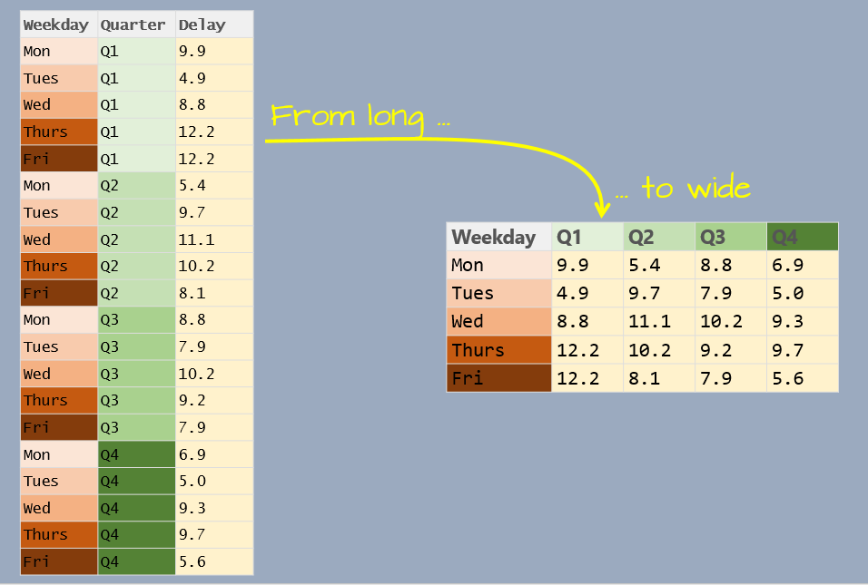

If a table is to be used for a visual assessment of the values, a long format may be difficult to work with. A long table can be re-expressed into a wide form by picking the two variables that will define the column names and column values.

Continuing with our earlier example, we will convert `df.long` back to a wide format using the `pivot_wider()` function. This replaces the `spread()` function from earlier versions of `tidyr` (<`1.0`). The `pivot_wider()` function takes at least two arguments:

- `names_from`: Column whose values will be converted to column names.
- `values_from`: Column whose values will populate the table’s block of cell values.

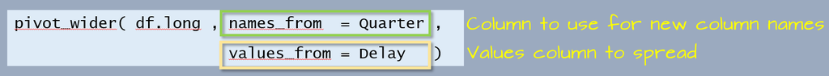

```r
df.wide <- pivot_wider(df.long, names_from = Quarter, values_from = Delay)
df.wide
```

```
# A tibble: 5 x 5
  Weekday    Q1    Q2    Q3    Q4
  <fct>   <dbl> <dbl> <dbl> <dbl>
1 Mon       9.9   5.4   8.8   6.9
2 Tues      4.9   9.7   7.9   5
3 Wed       8.8  11.1  10.2   9.3
4 Thurs    12.2  10.2   9.2   9.7
5 Fri      12.2   8.1   7.9   5.6
```

## Advanced `pivot_longer` options

Here’s a subset of median income by sex *and* by work experience for 2017.

```r
df2 <- data.frame( state = c("Maine", "Massachusetts",
                             "New Hampshire", "Vermont"),
                   male_fulltime = c(50329,66066, 59962, 50530),
                   male_other = c(18099, 18574, 20274, 17709),
                   female_fulltime = c(40054, 53841, 46178, 42198),
                   female_other = c(13781, 14981, 15121, 14422))
df2
```

```
          state male_fulltime male_other female_fulltime female_other
1         Maine         50329      18099           40054        13781
2 Massachusetts         66066      18574           53841        14981
3 New Hampshire         59962      20274           46178        15121
4       Vermont         50530      17709           42198        14422
```

At first glance, it might seem that we have three variables as in the earlier example, but upon closer examination, we see that we can tease out two variables from the column names: sex (`male` and `female`) and work experience (`fulltime` and `other`).

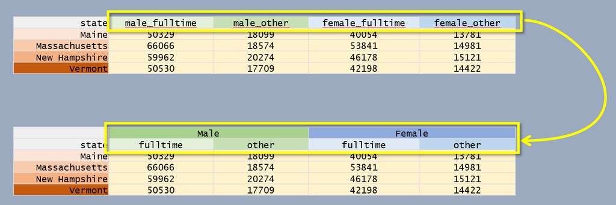

`pivot_longer` has an argument, `names_sep`, that is passed the character that is used to delimit the two variable values. In our example, this character is `_`. Since the column values will be split across two variables we will also need to pass **two** column names to the `names_to` argument.

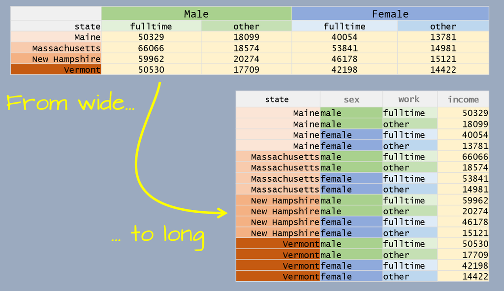

```r
df2.long <- pivot_longer(df2, cols=-1, names_to = c("sex","work"),
                         names_sep = "_", values_to = "income")
df2.long
```

```
# A tibble: 16 x 4
   state         sex    work     income
   <fct>         <chr>  <chr>     <dbl>
 1 Maine         male   fulltime  50329
 2 Maine         male   other     18099
 3 Maine         female fulltime  40054
 4 Maine         female other     13781
 5 Massachusetts male   fulltime  66066
 6 Massachusetts male   other     18574
 7 Massachusetts female fulltime  53841
 8 Massachusetts female other     14981
 9 New Hampshire male   fulltime  59962
10 New Hampshire male   other     20274
11 New Hampshire female fulltime  46178
12 New Hampshire female other     15121
13 Vermont       male   fulltime  50530
14 Vermont       male   other     17709
15 Vermont       female fulltime  42198
16 Vermont       female other     14422
```

## Advanced `pivot_wider` options

### Combining variable names when spreading

Continuing with the `df2.long` dataframe, we can spread the long table back to a wide table while combining the `sex` and `work` variables. We’ll add the `names_sep` argument which defines the character to use to separate the two variable names. We’ll use a dot `.` separator in this example.

```r
pivot_wider(df2.long, names_from = c(sex,work), values_from = income,
            names_sep = ".")
```

```
# A tibble: 4 x 5
  state         male.fulltime male.other female.fulltime female.other
  <fct>                 <dbl>      <dbl>           <dbl>        <dbl>
1 Maine                 50329      18099           40054        13781
2 Massachusetts         66066      18574           53841        14981
3 New Hampshire         59962      20274           46178        15121
4 Vermont               50530      17709           42198        14422
```

### Spreading duplicate variable combinations

If your long table has more than one unique combination of variables, `pivot_wider()` will return a list. This differs from the `spread()`’s behavior which would have returned an error.

```r
df3 <- data.frame(var1 = c("a", "a", "b", "b"),
                  var2 = c("x", "x", "y", "y"),
                  val  = c(5,3,1,4))
df3
```

```
  var1 var2 val
1    a    x   5
2    a    x   3
3    b    y   1
4    b    y   4
```

```r
pivot_wider(df3, names_from = var2, values_from = val)
```

```
# A tibble: 2 x 3
  var1            x           y
  <fct> <list<dbl>> <list<dbl>>
1 a             [2]         [0]
2 b             [0]         [2]
```

```r
pivot_wider(df3, names_from = var2, values_from = val,
            values_fn = list(val = min))
```

```
# A tibble: 2 x 3
  var1      x     y
  <fct> <dbl> <dbl>
1 a         3    NA
2 b        NA     1
```

You’ll note the empty cells resulting from there not being a valid combination for `a`:`y` and `b`:`x`. You can specify the missing values using the `values_fill` argument. For example, to replace `NA` with `0` type:

```r
pivot_wider(df3, names_from = var2, values_from = val,
            values_fn   = list(val = min),
            values_fill = list(val = 0))
```

```
# A tibble: 2 x 3
  var1      x     y
  <fct> <dbl> <dbl>
1 a         3     0
2 b         0     1
```

## Separating elements in one column into separate columns

The `tidyr` package offers other functions not directly tied to pivoting. For example, to split a column into two or more columns based on a column’s delimited value, use the `separate()` function.

```r
# Let's first create a delimited table
df2.long <- pivot_longer(df2, cols=-1, names_to = "var1", values_to = "income")
df2.long
```

```
# A tibble: 16 x 3
   state         var1            income
   <fct>         <chr>            <dbl>
 1 Maine         male_fulltime    50329
 2 Maine         male_other       18099
 3 Maine         female_fulltime  40054
 4 Maine         female_other     13781
 5 Massachusetts male_fulltime    66066
 6 Massachusetts male_other       18574
 7 Massachusetts female_fulltime  53841
 8 Massachusetts female_other     14981
 9 New Hampshire male_fulltime    59962
10 New Hampshire male_other       20274
11 New Hampshire female_fulltime  46178
12 New Hampshire female_other     15121
13 Vermont       male_fulltime    50530
14 Vermont       male_other       17709
15 Vermont       female_fulltime  42198
16 Vermont       female_other     14422
```

```r
# Split var1 column into two columns
df2.sep <- separate(df2.long, col = var1, sep = "_", into = c("sex", "work"))
df2.sep
```

```
# A tibble: 16 x 4
   state         sex    work     income
   <fct>         <chr>  <chr>     <dbl>
 1 Maine         male   fulltime  50329
 2 Maine         male   other     18099
 3 Maine         female fulltime  40054
 4 Maine         female other     13781
 5 Massachusetts male   fulltime  66066
 6 Massachusetts male   other     18574
 7 Massachusetts female fulltime  53841
 8 Massachusetts female other     14981
 9 New Hampshire male   fulltime  59962
10 New Hampshire male   other     20274
11 New Hampshire female fulltime  46178
12 New Hampshire female other     15121
13 Vermont       male   fulltime  50530
14 Vermont       male   other     17709
15 Vermont       female fulltime  42198
16 Vermont       female other     14422
```

## Splitting rows into multiple rows based on delimited values

You can also split delimited values across rows.

```r
separate_rows(df2.long, var1, sep="_")
```

```
# A tibble: 32 x 3
   state         var1     income
   <fct>         <chr>     <dbl>
 1 Maine         male      50329
 2 Maine         fulltime  50329
 3 Maine         male      18099
 4 Maine         other     18099
 5 Maine         female    40054
 6 Maine         fulltime  40054
 7 Maine         female    13781
 8 Maine         other     13781
 9 Massachusetts male      66066
10 Massachusetts fulltime  66066
# ... with 22 more rows
```

Note that the output is a `tibble` even if the input is a dataframe.

## Replicate rows by count

You can expand rows based on a count column using the `uncount()` function. This is the opposite of a `group_by(...) %>% count()` operation that tallies up the observations based on a grouping variable. Here, we’ll replicate rows based on the column `count` value.

```r
df2b <- data.frame(var1= c("a", "b"), var2 = c("x", "y"), count = c(1, 3))
df2b
```

```
  var1 var2 count
1    a    x     1
2    b    y     3
```

```r
uncount(df2b, count)
```

```
    var1 var2
1      a    x
2      b    y
2.1    b    y
2.2    b    y
```

If you want to add an index column that identifies the replicated rows, add an `.id` argument.

```r
uncount(df2b, count, .id = "id")
```

```
    var1 var2 id
1      a    x  1
2      b    y  1
2.1    b    y  2
2.2    b    y  3
```

## Combining elements from many columns into a single column

The `unite()` function performs the opposite task of `separate`. It combines multiple columns into a single column by aggregating their values.

```r
df2.unite <- unite(df2.sep, col = "var1", sep = ",", sex, work)
df2.unite
```

```
# A tibble: 16 x 3
   state         var1            income
   <fct>         <chr>            <dbl>
 1 Maine         male,fulltime    50329
 2 Maine         male,other       18099
 3 Maine         female,fulltime  40054
 4 Maine         female,other     13781
 5 Massachusetts male,fulltime    66066
 6 Massachusetts male,other       18574
 7 Massachusetts female,fulltime  53841
 8 Massachusetts female,other     14981
 9 New Hampshire male,fulltime    59962
10 New Hampshire male,other       20274
11 New Hampshire female,fulltime  46178
12 New Hampshire female,other     15121
13 Vermont       male,fulltime    50530
14 Vermont       male,other       17709
15 Vermont       female,fulltime  42198
16 Vermont       female,other     14422
```

## Creating unique combinations of variable values

You can use `expand_grid` to automatically generate a table with unique combinations of a set of variable values. For example, to fill a table with a combination of student names and homework assignments, type:

```r
df3.long <- expand_grid(
  student    = c("Joe", "Jane", "Kim"),  # Define all unique student names
  assignment = c(paste0("HW", 1:4)),     # Define all unique HW assignments
  value      = NA)
df3.long
```

```
# A tibble: 12 x 3
   student assignment value
   <chr>   <chr>      <lgl>
 1 Joe     HW1        NA
 2 Joe     HW2        NA
 3 Joe     HW3        NA
 4 Joe     HW4        NA
 5 Jane    HW1        NA
 6 Jane    HW2        NA
 7 Jane    HW3        NA
 8 Jane    HW4        NA
 9 Kim     HW1        NA
10 Kim     HW2        NA
11 Kim     HW3        NA
12 Kim     HW4        NA
```

We can then create a wide version of the table using `pivot_wider`.

```r
pivot_wider(df3.long, names_from = assignment, values_from = value)
```

```
# A tibble: 3 x 5
  student HW1   HW2   HW3   HW4
  <chr>   <lgl> <lgl> <lgl> <lgl>
1 Joe     NA    NA    NA    NA
2 Jane    NA    NA    NA    NA
3 Kim     NA    NA    NA    NA
```

## Filling gaps in a table with `NA`

It’s not uncommon to be handed a table with incomplete combinations of observations. For example, the following table gives us yield and data source values for each combination of year and grain type. However, several combinations of year/grain are missing.

```r
df4.long <- data.frame( Year  = c(1999,1999,2000,2000,2001,2003,2003,2005),
                        Grain = c("Oats", "Corn","Oats", "Corn","Oats", "Oats", "Corn","Oats"),
                        Yield = c(23,45,24,40,20,19,41,22),
                        Src   = c("a","a","b","c","a","a","c","a"),
                        stringsAsFactors = FALSE)
df4.long
```

```
  Year Grain Yield Src
1 1999  Oats    23   a
2 1999  Corn    45   a
3 2000  Oats    24   b
4 2000  Corn    40   c
5 2001  Oats    20   a
6 2003  Oats    19   a
7 2003  Corn    41   c
8 2005  Oats    22   a
```

```r
df.all <- complete(df4.long, Year=1999:2005, Grain=  c("Oats", "Corn"),
                   fill = list(Yield = 0, Src = NA))
df.all
```

```
# A tibble: 14 x 4
    Year Grain Yield Src
   <dbl> <chr> <dbl> <chr>
 1  1999 Corn     45 a
 2  1999 Oats     23 a
 3  2000 Corn     40 c
 4  2000 Oats     24 b
 5  2001 Corn      0 <NA>
 6  2001 Oats     20 a
 7  2002 Corn      0 <NA>
 8  2002 Oats      0 <NA>
 9  2003 Corn     41 c
10  2003 Oats     19 a
11  2004 Corn      0 <NA>
12  2004 Oats      0 <NA>
13  2005 Corn      0 <NA>
14  2005 Oats     22 a
```

If you want to show just the missing rows, use `dplyr::anti_join()`.

```r
dplyr::anti_join(df.all, df4.long)
```

```
# A tibble: 6 x 4
   Year Grain Yield Src
  <dbl> <chr> <dbl> <chr>
1  2001 Corn      0 <NA>
2  2002 Corn      0 <NA>
3  2002 Oats      0 <NA>
4  2004 Corn      0 <NA>
5  2004 Oats      0 <NA>
6  2005 Corn      0 <NA>
```

## Identifying missing combination in dataframes

In the previous example, we had the function automatically add the missing combinations using **explicitly** defined ranges of values. If you just want to output the missing combinations from the **existing** set of values in both columns, use the `expand()` function.

```r
p.all <- expand(df4.long, Year, Grain) # List all possible combinations
p.all
```

```
# A tibble: 10 x 2
    Year Grain
   <dbl> <chr>
 1  1999 Corn
 2  1999 Oats
 3  2000 Corn
 4  2000 Oats
 5  2001 Corn
 6  2001 Oats
 7  2003 Corn
 8  2003 Oats
 9  2005 Corn
10  2005 Oats
```

Note that this only outputs the columns of interest. If you need to see the other columns in the output, perform a join.

```r
dplyr::left_join(p.all, df4.long, by=c("Year", "Grain"))
```

```
# A tibble: 10 x 4
    Year Grain Yield Src
   <dbl> <chr> <dbl> <chr>
 1  1999 Corn     45 a
 2  1999 Oats     23 a
 3  2000 Corn     40 c
 4  2000 Oats     24 b
 5  2001 Corn     NA <NA>
 6  2001 Oats     20 a
 7  2003 Corn     41 c
 8  2003 Oats     19 a
 9  2005 Corn     NA <NA>
10  2005 Oats     22 a
```

## Auto-fill down or up

The `fill()` function is used to replace `NA` values with the closest non-`NA` value in a column. For example, to fill *down*, set the `.direction` argument to `"down"`.

```r
df5 <- data.frame(Month = 1:12,
                 Year = c(2000, rep(NA, 4),2001, rep(NA,6)))
df5
```

```
   Month Year
1      1 2000
2      2   NA
3      3   NA
4      4   NA
5      5   NA
6      6 2001
7      7   NA
8      8   NA
9      9   NA
10    10   NA
11    11   NA
12    12   NA
```

```r
fill(df5, Year, .direction="down")
```

```
   Month Year
1      1 2000
2      2 2000
3      3 2000
4      4 2000
5      5 2000
6      6 2001
7      7 2001
8      8 2001
9      9 2001
10    10 2001
11    11 2001
12    12 2001
```

Manuel Gimond, 2019